# Decoding IPL Dynamics: A Data Visualization Exploration

# How did you apply the principles of data visualizations and design for this visualization?

The principles of data visualization and design were applied by selecting an appropriate chart type (bar plot) to display the categorical data (season) against the quantitative data (number of teams). The use of a minimal theme ensures clarity and focus on the data, while labeling the axes and providing a title adds context and clarity to the plot. Additionally, scaling the y-axis to display integer values ensures that the chart accurately represents the count of teams without decimal points, facilitating easier interpretation of the data.

# Finding which team is winner in each season with the number of wins.

```r
season_winners <- matches %>%
  group_by(season, winner) %>%
  summarize(wins = n()) %>%
  arrange(season, desc(wins)) %>%
  slice(1) %>% # Select the team with the most wins for each season
  select(season, winner,wins)
# Print the result
print(season_winners)
```

```
## # A tibble: 12 × 3
## # Groups:   season [12]
##    season winner                 wins
##     <dbl> <chr>                 <int>
##  1   2008 Rajasthan Royals         13
##  2   2009 Delhi Daredevils         10
##  3   2010 Mumbai Indians           11
##  4   2011 Chennai Super Kings      11
##  5   2012 Kolkata Knight Riders    12
##  6   2013 Mumbai Indians           13
##  7   2014 Kings XI Punjab          12
##  8   2015 Chennai Super Kings      10
##  9   2016 Sunrisers Hyderabad      11
## 10   2017 Mumbai Indians           12
## 11   2018 Chennai Super Kings      11
## 12   2019 Mumbai Indians           11
```

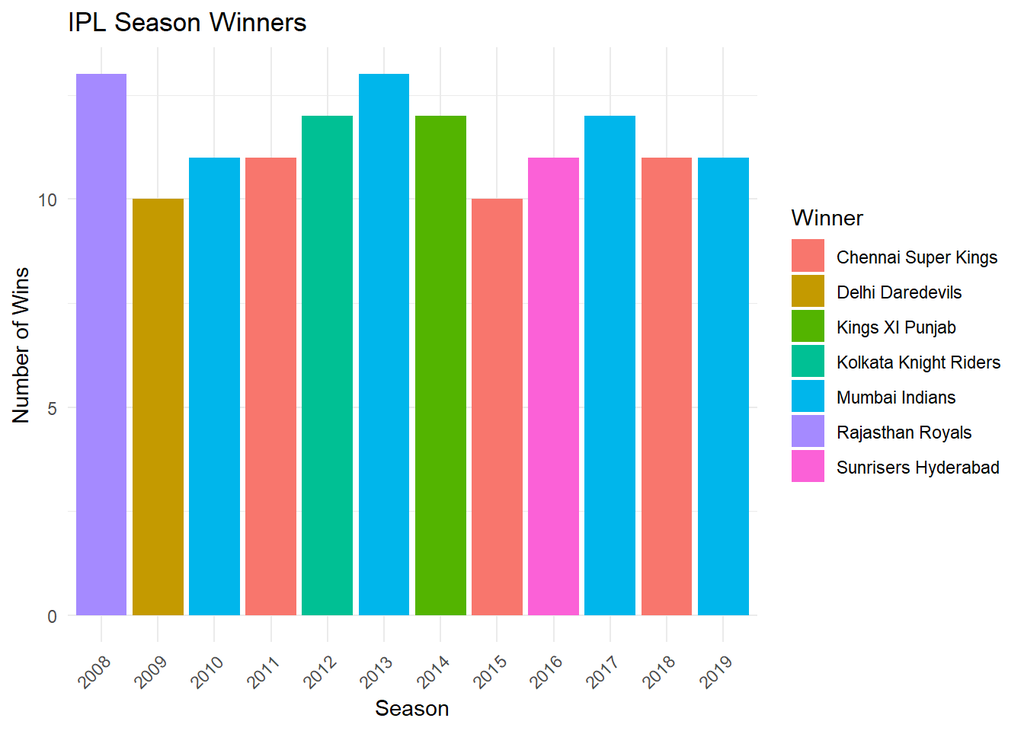

```r
ggplot(season_winners, aes(x = factor(season), y = wins, fill = winner)) +
  geom_bar(stat = "identity") +
  labs(title = "IPL Season Winners",
       x = "Season",
       y = "Number of Wins",
       fill = "Winner") +
  theme_minimal() +
  theme(axis.text.x = element_text(angle = 45, hjust = 1)) +
  guides(fill = guide_legend(title = "Winner"))
```

# What were the original charts you planned to create for this visualization?

The original plan was to create a bar chart visualizing the number of wins by each winning team in each IPL season.

# What story could you tell with your plot?

The plot showcases the winning team for each IPL season along with the number of wins they achieved. It highlights the dominance of certain teams across different seasons and provides insights into the performance trends of IPL teams over time.The consistent wins of team may help building a good brand value over the time.This may help more income to players playing in respective teams and also can help in having better training equipment for practicing the game.

# How did you apply the principles of data visualizations and design for this visualization?

The plot data in a straightforward bar chart format, with each bar representing the number of wins for a specific team in a season. The colors are used effectively to distinguish between different winning teams, aiding in easy identification. The chart is labeled clearly, with informative titles for both axes and a legend to explain the color scheme.The theme Adjusts the angle of the x-axis labels to 45 degrees for better readability at years.

# Checking in which city most of the matches were played

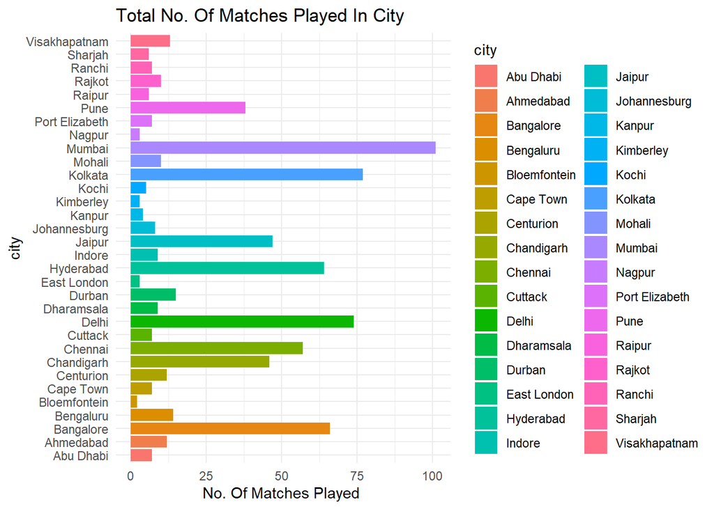

```r
ggplot(matches[which(!is.na(matches$city)),],
       aes(city,fill=city,rm.na=T))+
        geom_bar()+
        guides(TRUE)+
        coord_flip()+
        theme_minimal()+
  labs(title = "Total No. Of Matches Played In City")+
       ylab("No. Of Matches Played ")
```

# What were the original charts you planned to create for this visualization?

The original intention was to create a bar chart showing the distribution of matches played across different cities.

# What story could you tell with your plot?

The plot depicts the total number of matches played in each city, providing insights into where most IPL matches have been held over the years. It showcases the cities that have hosted a significant number of matches, revealing patterns of match distribution across different locations.This may also influence has people come to watch match in a particular stadium may increase the tourists travel to city.The city may be get more economy than the regular days.

# How did you apply the principles of data visualizations and design for this visualization?

The plot effectively communicates the distribution of matches across cities, with each bar representing the total number of matches played in a specific city. The use of color (fill) distinguishes between different cities, aiding in easy identification. Additionally, flipping the coordinates (coord_flip) makes the bars horizontal for better readability.guides(TRUE): Displaythe legend, indicating the mapping of fill colors to city names.

# A batsman Virat Kohli dissmisal

```r
virat_dismissals <- deliveries %>%
  filter(player_dismissed == "V Kohli") %>%
  group_by(dismissal_kind) %>%
  summarise(times_dismissed = n())


virat_dismissals
```

```
## # A tibble: 6 × 2
##   dismissal_kind    times_dismissed
##   <chr>                       <int>
## 1 bowled                         30
## 2 caught                         95
## 3 caught and bowled               2
## 4 lbw                             7
## 5 run out                         6
## 6 stumped                         3
```

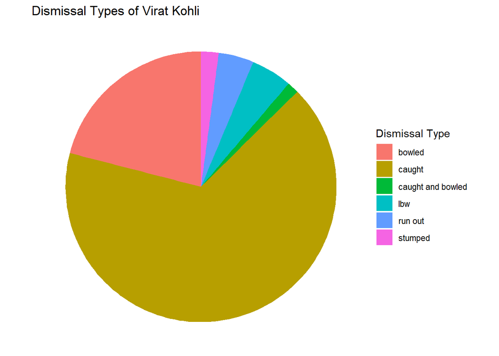

```r
# Create pie chart for Virat Kohli's dismissal types
ggplot(virat_dismissals, aes(x = "", y = times_dismissed, fill = dismissal_kind)) +
  geom_bar(stat = "identity") +
  coord_polar("y") +
  labs(title = "Dismissal Types of Virat Kohli",
       fill = "Dismissal Type") +
  theme_void()
```

# What were the original charts you planned to create for this visualization?

The original chart planned for this visualization was a pie chart depicting the dismissal types of Virat Kohli in IPL matches.

# What story could you tell with your plot?

The plot portrays the distribution of dismissal types experienced by Virat Kohli throughout his IPL career. Each segment of the pie chart represents a specific dismissal type, such as caught, bowled, lbw, etc., and the size of each segment reflects the proportion of times Virat Kohli was dismissed in that manner. By examining this visualization, viewers can gain insights into the most common modes of dismissal for one of cricket’s top players.This spots may be his weak points where he can get out and a good learning thing for him to overcome his weakness.

# How did you apply the principles of data visualizations and design for this visualization?